# Indexação

Nicholas A. C. Marino

nac.marino@gmail.com

github.com/nacmarino/introducaoR

# Elementos da Aula

1. Indexação
2. Indexação de vetores
3. Indexando `data.frame`
4. Indexando listas

## Indexação

- Indexação é a ação de extrair um elemento específico, ou um conjunto de elementos, de um objeto.
- Cada objeto criado pode ser descrito por um conjunto de dimensões (copie e rode os exemplos junto de cada caso abaixo):
  1. um `vector` possui apenas uma dimensão: o seu comprimento linear.
     - `vetor1`
  2. uma `matrix` possui duas dimensões: as linhas e as coluna:
     - `matrix(c(vetor1, vetor2), ncol = 2)`
     - um `array` é um caso especial de matriz com mais de duas dimensões: e.g. `array(0, dim = c(2, 4, 3))`
  3. uma `list` possui uma ou mais dimensões: sub-listas, compostas por uma ou sub-listas e as dimensões dos objetos que as compõem:
     - `list(vetor1, vetor2, list(vetor1, vetor2), list(list(vetor1, vetor2), vetor1))`
  4. um `data.frame` possui apenas duas dimensões: as linhas e as colunas:
     - `data.frame(vetor1, vetor2)`
- Note que, em cada um destes casos, cada elemento pode ser rastreado até uma posição específica. Por exemplo:
  - no `vetor1` que criamos anteriormente, o número 7 ocupa a sétima posição na sequência;
  - em `list(vetor1, vetor2)`, o número 100 ocupa a 34a. posição da segunda lista;
  - em `data.frame(vetor1, vetor2)`, o número 0 ocupa a primeira linha a segunda coluna.
- Assim, podemos extrair sub-conjuntos específicos de dados de acordo com as ‘coordenadas’ dos dados que queremos, como em um jogo de batalha naval.

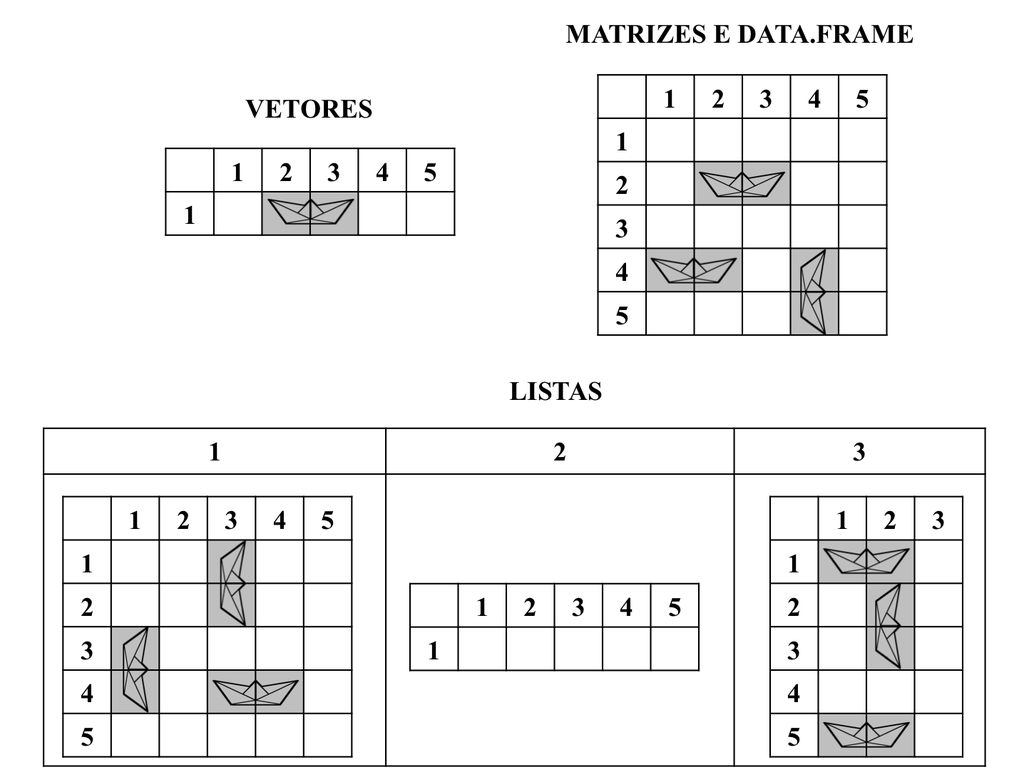

- Utilizaremos três tipos de operadores para realizar a indexação:
  1. `[]` extrai um ou mais elementos em vetores, listas, ou `data.frame`;
  2. `[[]]` extrai um ou mais elementos em listas ou `data.frame`;
  3. `$` extrai elementos pelo **nome** em listas e `data.frame`.

### Indexando Vetores

- Por exemplo, se quisermos extrair o 16o. elemento do `vetor2`, podemos usar:

```r
vetor2 <- seq(from = 0, to = 100, length.out = 34)
vetor2
```

```
##  [1]   0.000000   3.030303   6.060606   9.090909  12.121212  15.151515
##  [7]  18.181818  21.212121  24.242424  27.272727  30.303030  33.333333
## [13]  36.363636  39.393939  42.424242  45.454545  48.484848  51.515152
## [19]  54.545455  57.575758  60.606061  63.636364  66.666667  69.696970
## [25]  72.727273  75.757576  78.787879  81.818182  84.848485  87.878788
## [31]  90.909091  93.939394  96.969697 100.000000
```

```r
vetor2[16]
```

```
## [1] 45.45455
```

- Podemos extrair sequências de elementos em um vetor de forma similar àquela que usamos acima:

```r
# extraindo do 16o. ao 21o. elemento do vetor2
vetor2[16:21]
```

```
## [1] 45.45455 48.48485 51.51515 54.54545 57.57576 60.60606
```

- Mas o que estamos fazendo ao fornecer esta sequência de números? Compare:

```r
# criando uma sequência de número de 16 a 21
(numeros <- 16:21)
```

```
## [1] 16 17 18 19 20 21
```

```r
# indexando o vetor2 para extrair do 16o. ao 21o. elemento
vetor2[16:21]
```

```
## [1] 45.45455 48.48485 51.51515 54.54545 57.57576 60.60606
```

```r
# indexando o vetor2 para extrair os valores de acordo com a sequencia criada
vetor2[numeros]
```

```
## [1] 45.45455 48.48485 51.51515 54.54545 57.57576 60.60606
```

- A indexação está usando um vetor de um ou mais elementos - este vetor marca a posição dos elementos a serem retidos.
- Assim, poderíamos criar um vetor com números representando posições específicas que queremos reter:

```r
numeros <- c(1, 5, 7, 9)
vetor2[numeros]
```

```
## [1]  0.00000 12.12121 18.18182 24.24242
```

```r
vetor2[c(1, 5, 7, 9)]
```

```
## [1]  0.00000 12.12121 18.18182 24.24242
```